# How-to Feldexperiment

Anleitung für Wahlkämpfer*innen im Wahlkreis 281

Autor:in

Anton Könneke

[Zuhör-Gesprächsleitfaden](https://antonkoenneke.de/_files/share/wk281_RCT_GE2025/listening_script_freiburg.html) [Info-Gesprächsleitfaden](https://antonkoenneke.de/_files/share/wk281_RCT_GE2025/info_script_freiburg.html) [TzT-Linktree](https://linktr.ee/wk281_tzt)

## Worum geht’s?

Die Kampagne steht unter dem Motto “Zuhören” und das wollen wir auch im Haustürwahlkampf verkörpern. Darum nehmen wir uns dieses Jahr für einige Gespräche mehr Zeit und horchen uns um, wo der Schuh drückt.

Mit dem Feldexperiment testen wir, wie effektiv unsere Zuhörstrategie im Vergleich zu klassischem TzT Wahlkampf ist. Damit das klappt, ist es wichtig, dass Ihr ein paar Dinge beachtet.

## 1 Ablauf TzT-Experiment

1. TzT App einrichten und Gebiet auswählen.
2. Oberste Postkarte vom Stapel ziehen und checken ob **Z** oder **I** vor dem Zahlencode unten links steht.
   1. Bei **Z**: an der Haustür ein **Zuhörgespräch** durchführen.
   2. Bei **I**: an der Haustür ein **Infogespräch** durchführen.
3. Nach jedem Gespräch **Infomaterial** und die **Postkarte übergeben.**
4. Angaben in TzT-App machen.
5. Neue Karte, neue Tür, usw.
6. Am Ende der Aktion sammelt die übrigen Postkarten gemeinsam mit den übrig gebliebenen Flyern bitte ein. Sie können wiederverwendet werden und wir müssen am Ende wissen, wie viele *nicht* verteilt wurden!

[figure not shown]

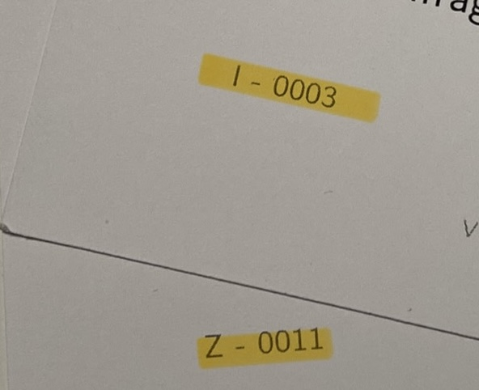

Codes “I” und “Z”

## 2 Was muss ich beachten?

- **Wichtig:** Auf keinen Fall dürfen die Karten nach Z/I sortiert werden. Ebenso wichtig ist, dass Ihr **wirklich die oberste Karte** nehmt und nicht gezielt nach einer I-Karte oder einer Z-Karte sucht. Das würde unsere Ergebnisse verfälschen, im schlimmsten Fall mit der Konsequenz, dass wir in künftige TzT-Kampagnen anhand falscher Informationen planen und unser Wahlkampf so weniger effektiv wird.
- Wenn eine Tür nicht geöffnet wird, könnt ihr die gleiche Postkarte einfach an der nächsten Tür wiederverwerten.
- Denkt daran, vor dem Klopfen eine Karte zu ziehen. Nehmt Euch kurz Zeit um Euch den entsprechenden Gesprächsleitfaden zur vergegenwärtigen.
- Übergebt genau die Karte, die ihr vor dem Klopfen gezogen habt und die über den Gesprächsleitfaden entschieden hat.
- Übergebt die Karte nur persönlich, also wenn ein Gespräch stattgefunden hat. Bitte werft sie nicht in den Briefkasten o.Ä.
- Wenn Ihr nicht alle Postkarten verteilt, sammelt die restlichen Postkarten am Ende mit den SPD-Flyern ein und gebt sie z.B. der/dem OV-Vorsitzenden mit. Wir müssen am Ende des Wahlkampfes wissen, wie viele Postkarten (nicht) verteilt wurden um Ergebnisse zu erhalten.
- Solltet Ihr das Einsammeln einmal vergessen, lasst Anton bitte wissen wie viele I- und Z-Karten Ihr noch habt. Ihr erreicht mich unter a.konneke@lse.ac.uk oder +49 157 88122549 (WhatsApp).
- Erklärt beim Übergeben der Postkarte kurz, dass man der SPD so Feedback geben / mitteilen kann, was einem auf dem Herzen liegt.

## 3 Hintergrund

Um zu testen, wie gut die Zuhörgespräche im Vergleich zu den kurzen Infogesprächen funktionieren, werden Menschen mit der Postkarte zu einer Umfrage eingeladen, in der Sie uns Ihre wichtigsten Themen mitteilen können.

**Jede** **Postkarte hat einen QR-Code mit einem individuellen Link zur Umfrage, der die Information enthält, ob ein Zuhör- oder Informationsgespräch stattfand. Darum ist es wichtig, dass Ihr Euch an die Z/I Angaben auf der Postkarte haltet.**

In dieser Umfrage fragen wir nach den wichtigsten Themen der Bürger:innen aber auch nach ihrer geplanten Wahlentscheidung und ihren Einstellungen zu Politik generell.

## 4 Alles weitere…

Wenn etwas unklar ist und nachgebessert werden muss, kontaktiert mich gern unter a.konneke@lse.ac.uk oder +49 157 88122549.